# Report Fraud Prediction

Hannes Guth

2022-12-20

# Project report

## Data reading and preparation

At first, the libraries that will be needed throughout the document are loaded.

```r
library(data.table) # package to handle data tables
library(caret)
library(neuralnet) # used to run neural networks
library(compiler) # used to compile functions to save computational time
library(dplyr) # used for the pipe operator
library(rpart) # used for running regression trees
library(NeuralNetTools)
library(ggplot2) # used to produce different visualizations
library(randomForest) # used to run random forests
library(pROC)
library(caTools)
library(ROCR)
library(knitr) # used to show tables
```

In this section, the data that were previously prepared in Python will be loaded as data tables. 6 files will be loaded, one test set, one training set and one validation set. Since the isFraud-information is stored as an extra column for each set, these information will also be loaded.

```r
setwd("D:/Dokumente/Studium/Master/Université de Genève/Kurse/Creating Value Through Data Mining/Project/Daten") # set the working directory

freadFast <- cmpfun(fread) # compile fread

# read the datasets that were previously prepared in python
testx <- fread("x_group_main_types_test.csv")
trainx <- fread("x_group_main_types_train.csv")
validationx <- fread("x_group_main_types_validation.csv")
testy <- fread("y_group_main_types_test.csv")
trainy <- fread("y_group_main_types_train.csv")
validationy <- fread("y_group_main_types_validation.csv")
```

Since, only 8 variables will be kept these are first set. Then the datasets will be reduced to these 8 columns and also merged with the isFraud outcome column.

```r
# set the most important 8 variables
top8 <- c('oldbalanceOrg',
          'step',
          'std_amount',
          'std_oldbalanceOrg',
          'std_oldbalanceDest',
          'amount_is_equal_to_balance',
          'newbalanceDest',
          'debt',
          'isFraud')

# merge the data with their Fraud/non-fraud observations and only keep the important variables in the sets
test <- data.table(testx, testy)[, ..top8]
train <- data.table(trainx, trainy)[, ..top8]
validation <- data.table(validationx, validationy)[, ..top8]

# remove the datasets that were initially loaded
rm(testx, testy, validationx, validationy, trainx, trainy)

# convert the isFraud column to factors
test$isFraud <- as.factor(test$isFraud)
train$isFraud <- as.factor(train$isFraud)
validation$isFraud <- as.factor(validation$isFraud)

# Sample training set again because some parts cannot be executed with the whole training set due to computational time

# create a random sample
set.seed(1) # reproducibility
randTrainSmall = sample(seq_len(nrow(train)), size = 0.003*nrow(train)) # get approximately 4,000 random indices from the training set
randTrainSmall = train[randTrainSmall,] # get the values corresponding to these indices

# create a balanced sample
trainSmall <- as.data.table(train %>% # from the train data
  group_by(isFraud) %>% # the column that shall be grouped by is isFraud
  sample_n(size=as.integer(train[,.N,by=isFraud][1,2])/2)) # it shall take half of the fraud observations and exactly so many non fraud observations
```

## Baseline models

In this paragraph, the baseline models will be calculated and their performances evaluated.

```r
# nothing is Fraud
confusionMatrix(as.factor(integer(nrow(test))), test$isFraud, positive = "1")
```

```
## Confusion Matrix and Statistics
##
##           Reference
## Prediction      0      1
##          0 554256   1644
##          1      0      0
##
##                Accuracy : 0.997
##                  95% CI : (0.9969, 0.9972)
##     No Information Rate : 0.997
##     P-Value [Acc > NIR] : 0.5066
##
##                   Kappa : 0
##
##  Mcnemar's Test P-Value : <2e-16
##
##             Sensitivity : 0.000000
##             Specificity : 1.000000
##          Pos Pred Value :      NaN
##          Neg Pred Value : 0.997043
##              Prevalence : 0.002957
##          Detection Rate : 0.000000
##    Detection Prevalence : 0.000000
##       Balanced Accuracy : 0.500000
##
##        'Positive' Class : 1
##
```

```r
# everything is Fraud
confusionMatrix(as.factor(rep(1, nrow(test))), test$isFraud, positive = "1")
```

```
## Confusion Matrix and Statistics
##
##           Reference
## Prediction      0      1
##          0      0      0
##          1 554256   1644
##
##                Accuracy : 0.003
##                  95% CI : (0.0028, 0.0031)
##     No Information Rate : 0.997
##     P-Value [Acc > NIR] : 1
##
##                   Kappa : 0
##
##  Mcnemar's Test P-Value : <2e-16
##
##             Sensitivity : 1.000000
##             Specificity : 0.000000
##          Pos Pred Value : 0.002957
##          Neg Pred Value :      NaN
##              Prevalence : 0.002957
##          Detection Rate : 0.002957
##    Detection Prevalence : 1.000000
##       Balanced Accuracy : 0.500000
##
##        'Positive' Class : 1
##
```

```r
# if amount is equal to balance, than it is fraud
amountEquToBalance <- as.factor(ifelse(test$amount_is_equal_to_balance > 0, 1, 0))
confusionMatrix(amountEquToBalance, test$isFraud, positive = "1")
```

```
## Confusion Matrix and Statistics
##
##           Reference
## Prediction      0      1
##          0 554256     37
##          1      0   1607
##
##                Accuracy : 0.9999
##                  95% CI : (0.9999, 1)
##     No Information Rate : 0.997
##     P-Value [Acc > NIR] : < 2.2e-16
##
##                   Kappa : 0.9886
##
##  Mcnemar's Test P-Value : 3.252e-09
##
##             Sensitivity : 0.977494
##             Specificity : 1.000000
##          Pos Pred Value : 1.000000
##          Neg Pred Value : 0.999933
##              Prevalence : 0.002957
##          Detection Rate : 0.002891
##    Detection Prevalence : 0.002891
##       Balanced Accuracy : 0.988747
##
##        'Positive' Class : 1
##
```

An interpretation will be given in the report.

## Logistic Model

The model will be run with default values and on the whole training set.

```r
glmFast <- cmpfun(glm)
logistic_model <- glmFast(isFraud ~ ., data = train, family = "binomial") # create the logistic model

# Calculate the accuracy of the logistics regression model
log_predict <- predict(logistic_model, test, type = "response")

# 1. draw classification from the probabilities with a cutoff value of 0.5
log_predict <- ifelse(log_predict > 0.5, 1,0)

# 2. Evaluating the model performance
confusionMatrix(as.factor(test$isFraud), as.factor(log_predict))
```

```
## Confusion Matrix and Statistics
##
##           Reference
## Prediction      0      1
##          0 554254      2
##          1      8   1636
##
##                Accuracy : 1
##                  95% CI : (1, 1)
##     No Information Rate : 0.9971
##     P-Value [Acc > NIR] : <2e-16
##
##                   Kappa : 0.9969
##
##  Mcnemar's Test P-Value : 0.1138
##
##             Sensitivity : 1.0000
##             Specificity : 0.9988
##          Pos Pred Value : 1.0000
##          Neg Pred Value : 0.9951
##              Prevalence : 0.9971
##          Detection Rate : 0.9970
##    Detection Prevalence : 0.9970
##       Balanced Accuracy : 0.9994
##
##        'Positive' Class : 0
##
```

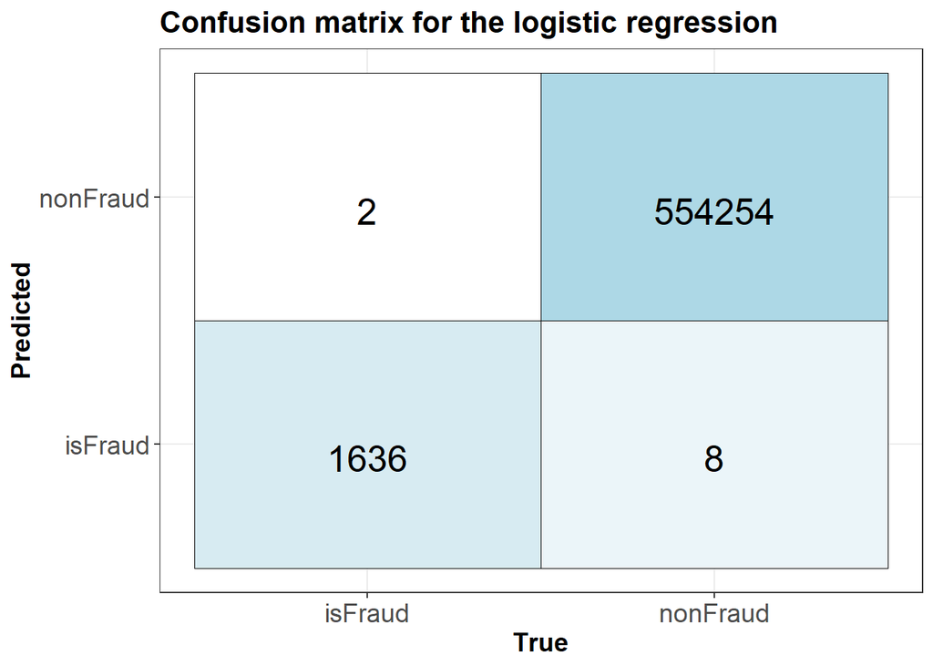

```r
Predicted <- factor(c("nonFraud", "isFraud", "isFraud", "nonFraud")) # set the possible outcomes for the predictions
True <- factor(c("nonFraud", "nonFraud", "isFraud", "isFraud")) # set the possible outcomes for the true values
Values <- c(554254, 8, 1636, 2) # set the number of values accordingly
Fill <- c(2,0.5,1,0) # create a vector for later colorization
data <- data.frame(True, Predicted, Values) # combine the created vectors

# Confusion matrix for the logistic model
ggplot(data = data, mapping = aes(x = True, y = Predicted)) + # create a new ggplot with the variables created above
  geom_tile(aes(fill = Fill), colour = "black") + # create a geom:tile element with the fill values from above
  geom_text(aes(label = sprintf("%1.0f", Values)), vjust = 1, size = 7) + # define the shape of the values in the plot
  scale_fill_gradient(low = "white", high = "lightblue") + # apply the above prepared filling
  theme_bw() + # set the bw theme
  theme(legend.position = "none", # no legend
        axis.text = element_text(size = 14), # define the font size of the axis texts
        axis.title = element_text(size = 14, face = "bold"), # define the font size of the axis title
        plot.title = element_text(size = 16, face = "bold")) + # define the font size of the plot title
  labs(title = "Confusion matrix for the logistic regression") # set the plot title
```

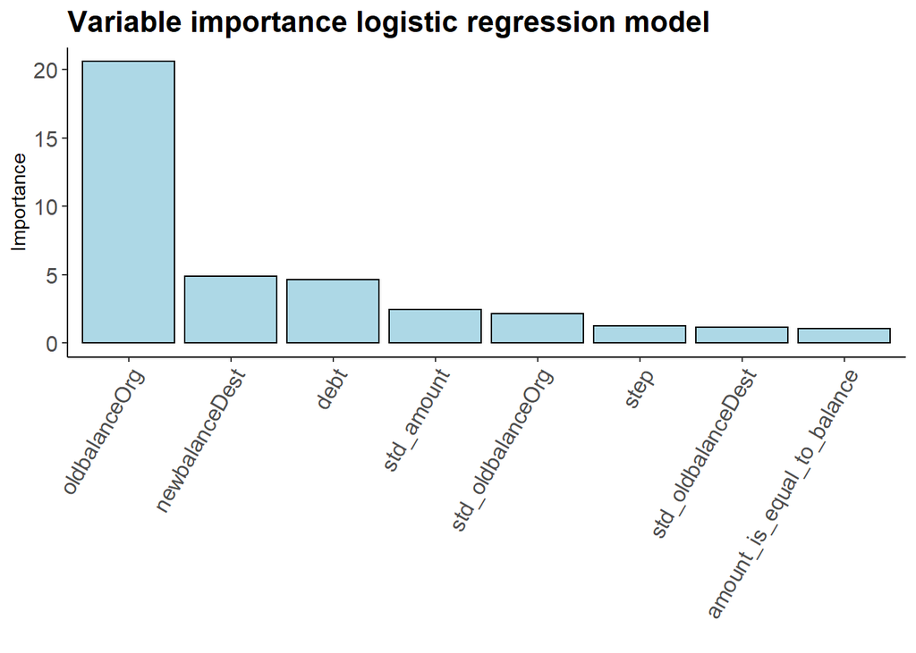

```r
importance <- varImp(logistic_model) # get the variable importance of the logistic model
importance$features <- row.names(importance) # get the rownames

ggplot(importance) + # create a new ggplot with importance as data
  geom_bar(stat = "identity", aes(x = reorder(features, -Overall), y = Overall), fill = "lightblue", color = "black") + # put features on the x-axis and importance on the y-axis
  theme(axis.text.x = element_text(angle = 60, vjust = 1, hjust = 1), # flip the x-axis labels
        panel.background = element_rect(fill = "white"), # set the background color to white
        axis.line = element_line(color = "black"), # set the line color to black
        axis.text = element_text(size = 12), # set the axis text size to 12
        plot.title = element_text(size = 16, face = "bold")) + # flip x-axis labels
  labs(title = "Variable importance logistic regression model", # set white background
       x = "", # set empty x-axis title
       y = "Importance") # set the title
```

## Classification Tree

### Finding the optimal maxdepth and cp

In this first section, a similar approach as for the neural networks will be done. Since it would be arbitrary to just set maxdepth and cp, the best combination will be searched by comparing the performance of trees with different combinations of these two variables on the two training datasets.

```r
treeCompute <- cmpfun(rpart) # compile the rpart function
predictFast <- cmpfun(predict) # compile the predict function

la = 25 # set the length to 25 because 5 variations in maxdepth x 5 variation in cp

# create an empty performance table
performance <- data.table("maxdepth" = integer(la),
                          "cp" = numeric(la),
                          "SensitivityBalanced" = numeric(la),
                          "SensitivityRandom" = numeric(la),
                          "SpecificityBalanced" = numeric(la),
                          "SpecificityRandom" = numeric(la),
                          "AccuracyBalanced" = numeric(la),
                          "AccuracyRandom" = numeric(la))

# create an empty results table
results <- data.table("Balanced" = numeric(nrow(test)),
                      "Random" = numeric(nrow(test)),
                      "True" = as.factor(test$isFraud))

options(scipen=999) # avoid scientific notation
counter = 0 # set the counter variable to 0

# go through "all" possible variations of maxdepth and cp
for (i in 1:5){ # got through all maxdepth levels
  cp = 1 # start everytime with cp = 1
  for (j in 1:5){ # go through all cp levels
    print(paste("i", i))
    print(paste("j", j))
    counter = counter + 1 # increase counter by 1
    cp = cp/10 # calculate a new cp-value
    set.seed(1) # reproducibility
    treeBalanced <- treeCompute(isFraud ~ ., data = trainSmall, method = "class", control = rpart.control(maxdepth = i, minbucket = 1, cp = cp)) # calculate the tree for the balanced training sample
    set.seed(1) # reproducibility
    treeRandom <- treeCompute(isFraud ~ ., data = randTrainSmall, method = "class", control = rpart.control(maxdepth = i, minbucket = 1, cp = cp)) # calculate the tree for the random training sample
    set.seed(1) # reproducibility
    results$Balanced <- predictFast(treeBalanced, test, type = 'class') # predict the results for the "balanced" tree for the test set
    results$Random <- predictFast(treeRandom, test, type = 'class') # predict the results for the "random" tree for the test set
    print("-")
    performance[counter, 1] = i # insert the current value of the maxdepth level
    performance[counter, 2] = round(cp, 5) # insert the current value of the cp level
    performance[counter, 3] = sensitivity(as.factor(results$Balanced), as.factor(results$True)) # calculate the sensitivity for the "balanced" tree
    performance[counter, 4] = sensitivity(as.factor(results$Random), as.factor(results$True)) # calculate the sensitivity for the "random" tree
    performance[counter, 5] = specificity(as.factor(results$Balanced), as.factor(results$True)) # calculate the specificity for the "balanced" tree
    performance[counter, 6] = specificity(as.factor(results$Random), as.factor(results$True)) # calculate the specificity for the "random" tree
    print("-")
    performance[counter,7] <- confusionMatrix(results$Balanced, results$True, positive = "1")$overall[1] # calculate the accuracy for the "balanced" tree
    performance[counter,8] <- confusionMatrix(results$Random, results$True, positive = "1")$overall[1] # calculate the accuracy for the "random" tree
  }
}
```

```
## [1] "i 1"
## [1] "j 1"
## [1] "-"
## [1] "-"
## [1] "i 1"
## [1] "j 2"
## [1] "-"
## [1] "-"
## [1] "i 1"
## [1] "j 3"
## [1] "-"
## [1] "-"
## [1] "i 1"
## [1] "j 4"
## [1] "-"
```

[output cut: 85 more lines]

```r
performance <- performance[order(-SensitivityBalanced),] # reorder it by SensitivityRandom
max(performance$SpecificityBalanced) # return the maximum value of the specificity for the "balanced" predictions
```

```
## [1] 0.9963504
```

```r
kable(performance) # show the performance table
```

| maxdepth | cp | SensitivityBalanced | SensitivityRandom | SpecificityBalanced | SpecificityRandom | AccuracyBalanced | AccuracyRandom |
| --- | --- | --- | --- | --- | --- | --- | --- |
| 1 | 0.10000 | 1.0000000 | 1 | 0.9774939 | 0.9774939 | 0.9999334 | 0.9999334 |
| 1 | 0.01000 | 1.0000000 | 1 | 0.9774939 | 0.9774939 | 0.9999334 | 0.9999334 |
| 1 | 0.00100 | 1.0000000 | 1 | 0.9774939 | 0.9774939 | 0.9999334 | 0.9999334 |
| 1 | 0.00010 | 1.0000000 | 1 | 0.9774939 | 0.9774939 | 0.9999334 | 0.9999334 |
| 1 | 0.00001 | 1.0000000 | 1 | 0.9774939 | 0.9774939 | 0.9999334 | 0.9999334 |
| 2 | 0.10000 | 1.0000000 | 1 | 0.9774939 | 0.9774939 | 0.9999334 | 0.9999334 |
| 3 | 0.10000 | 1.0000000 | 1 | 0.9774939 | 0.9774939 | 0.9999334 | 0.9999334 |
| 4 | 0.10000 | 1.0000000 | 1 | 0.9774939 | 0.9774939 | 0.9999334 | 0.9999334 |
| 5 | 0.10000 | 1.0000000 | 1 | 0.9774939 | 0.9774939 | 0.9999334 | 0.9999334 |
| 2 | 0.01000 | 0.9999802 | 1 | 0.9963504 | 0.9774939 | 0.9999694 | 0.9999334 |
| 2 | 0.00100 | 0.9999802 | 1 | 0.9963504 | 0.9774939 | 0.9999694 | 0.9999334 |
| 2 | 0.00010 | 0.9999802 | 1 | 0.9963504 | 0.9774939 | 0.9999694 | 0.9999334 |
| 2 | 0.00001 | 0.9999802 | 1 | 0.9963504 | 0.9774939 | 0.9999694 | 0.9999334 |
| 3 | 0.01000 | 0.9999802 | 1 | 0.9963504 | 0.9774939 | 0.9999694 | 0.9999334 |
| 3 | 0.00100 | 0.9999802 | 1 | 0.9963504 | 0.9774939 | 0.9999694 | 0.9999334 |
| 3 | 0.00010 | 0.9999802 | 1 | 0.9963504 | 0.9774939 | 0.9999694 | 0.9999334 |
| 3 | 0.00001 | 0.9999802 | 1 | 0.9963504 | 0.9774939 | 0.9999694 | 0.9999334 |
| 4 | 0.01000 | 0.9999802 | 1 | 0.9963504 | 0.9774939 | 0.9999694 | 0.9999334 |
| 4 | 0.00100 | 0.9999802 | 1 | 0.9963504 | 0.9774939 | 0.9999694 | 0.9999334 |
| 4 | 0.00010 | 0.9999802 | 1 | 0.9963504 | 0.9774939 | 0.9999694 | 0.9999334 |
| 4 | 0.00001 | 0.9999802 | 1 | 0.9963504 | 0.9774939 | 0.9999694 | 0.9999334 |
| 5 | 0.01000 | 0.9999802 | 1 | 0.9963504 | 0.9774939 | 0.9999694 | 0.9999334 |
| 5 | 0.00100 | 0.9999802 | 1 | 0.9963504 | 0.9774939 | 0.9999694 | 0.9999334 |
| 5 | 0.00010 | 0.9989554 | 1 | 0.9963504 | 0.9774939 | 0.9989477 | 0.9999334 |
| 5 | 0.00001 | 0.9989554 | 1 | 0.9963504 | 0.9774939 | 0.9989477 | 0.9999334 |

### Applying the best combination

For the big classification tree, the combination of maxdepth = 2 and cp = 0.01 is selected because SensitivityBalanced is very close to 1 and SensitivityRandom is 1 and SpecificityBalanced is the maximum achievable. SpecificityRandom does not change at all.

```r
tree <- treeCompute(isFraud ~ ., data = train, method = "class", control = rpart.control(maxdepth = 2, minbucket = 1, cp = 0.01)) # calculate the tree with the complete training set and the selected rpart.control values from above

# create the results table with predictions for the validation set and the true values
results <- data.table("Prediction" = predictFast(tree, test, type = 'class'),
                      "True" = as.factor(test$isFraud))
```

### Plotting the results

In the following, the performance will be evaluated, using a confusion matrix. This matrix will be generated in 2 ways.

```r
confusionMatrix(results$True, results$Prediction, positive = "1") # show the confusion matrix
```

```
## Confusion Matrix and Statistics
##
##           Reference
## Prediction      0      1
##          0 554254      2
##          1      6   1638
##
##                Accuracy : 1
##                  95% CI : (1, 1)
##     No Information Rate : 0.997
##     P-Value [Acc > NIR] : <0.0000000000000002
##
##                   Kappa : 0.9976
##
##  Mcnemar's Test P-Value : 0.2888
##
##             Sensitivity : 0.998780
##             Specificity : 0.999989
##          Pos Pred Value : 0.996350
##          Neg Pred Value : 0.999996
##              Prevalence : 0.002950
##          Detection Rate : 0.002947
##    Detection Prevalence : 0.002957
##       Balanced Accuracy : 0.999385
##
##        'Positive' Class : 1
##
```

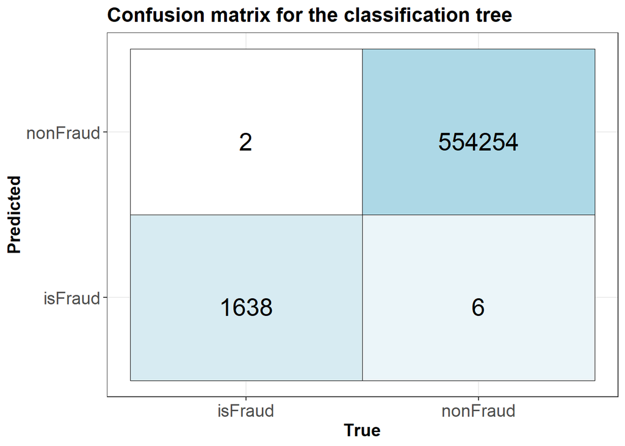

```r
Predicted <- factor(c("nonFraud", "isFraud", "isFraud", "nonFraud")) # set the possible outcomes for the predictions
True <- factor(c("nonFraud", "nonFraud", "isFraud", "isFraud")) # set the possible outcomes for the true values
Values <- c(554254, 6, 1638, 2) # set the number of values accordingly
Fill <- c(2,0.5,1,0) # create a vector for later colorization
data <- data.frame(True, Predicted, Values) # combine the created vectors

# Confusion matrix for the classification tree
ggplot(data = data, mapping = aes(x = True, y = Predicted)) + # create a new ggplot with the variables created above
  geom_tile(aes(fill = Fill), colour = "black") + # create a geom:tile element with the fill values from above
  geom_text(aes(label = sprintf("%1.0f", Values)), vjust = 1, size = 7) + # define the shape of the values in the plot
  scale_fill_gradient(low = "white", high = "lightblue") + # apply the above prepared filling
  theme_bw() + # set the bw theme
  theme(legend.position = "none", # no legend
        axis.text = element_text(size = 14), # define the font size of the axis texts
        axis.title = element_text(size = 14, face = "bold"), # define the font size of the axis title
        plot.title = element_text(size = 16, face = "bold")) + # define the font size of the plot title
  labs(title = "Confusion matrix for the classification tree") # set the plot title
```

Now, the variable importance plot will be generated.

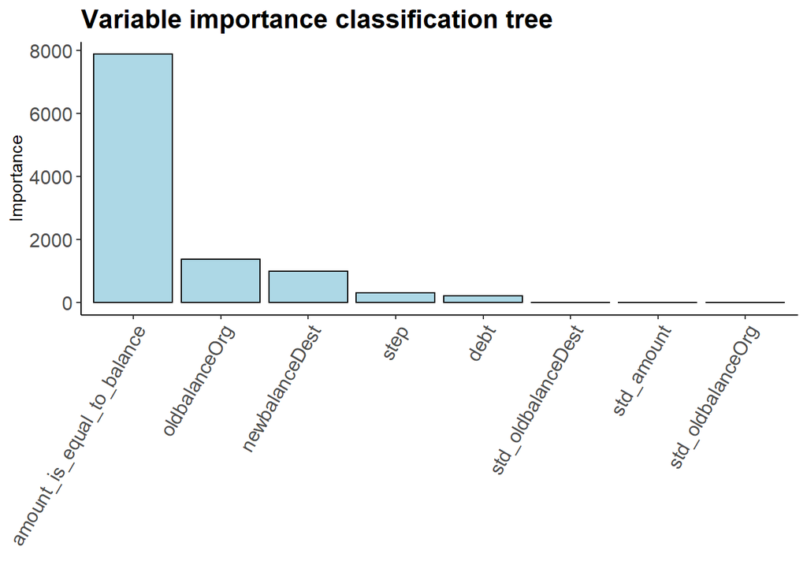

```r
importance <- varImp(tree) # getting variable importances
importance$features <- row.names(importance) # getting rownames as an extra column

ggplot(importance) + # create a new ggplot with importance as data
  geom_bar(stat = "identity", aes(x = reorder(features, -Overall), y = Overall), fill = "lightblue", color = "black") + # put features on the x-axis and importance on the y-axis
  theme(axis.text.x = element_text(angle = 60, vjust = 1, hjust = 1), # flip the x-axis labels
        panel.background = element_rect(fill = "white"), # set a white background
        axis.line = element_line(color = "black"), # set the line color to black
        axis.text = element_text(size = 12), # set the ext size to 12
        plot.title = element_text(size = 16, face = "bold")) + # set the size of the title
  labs(title = "Variable importance classification tree", # set the title
       x = "", # set empty x-axis title
       y = "Importance") # set the y-axis title
```

## Random Forest

### Running two models

In this part, the method “random Forest” will be applied to the dataset. Due to computational time, the model will only be trained on the the two small training samples and evaluated with the validation set. All values for the randomForest function will be kept at default.

```r
rndForest <- cmpfun(randomForest) # make the randomForest function faster
randForest <- rndForest(isFraud ~ ., data = randTrainSmall) # run with the random sample
BalancedForest <- rndForest(isFraud ~ ., data = trainSmall) # run with the balanced set
randPrediction <- predict(randForest, test) # predict with the "random" tree the data for the validation set
BalancedPrediction <- predict(BalancedForest, test) # predict with the "balanced" tree the data for the validation set
confusionMatrix(randPrediction, test$isFraud, positive = "1") # show the confusion matrix for the "random" prediction
```

```
## Confusion Matrix and Statistics
##
##           Reference
## Prediction      0      1
##          0 554256     37
##          1      0   1607
##
##                Accuracy : 0.9999
##                  95% CI : (0.9999, 1)
##     No Information Rate : 0.997
##     P-Value [Acc > NIR] : < 0.00000000000000022
##
##                   Kappa : 0.9886
##
##  Mcnemar's Test P-Value : 0.000000003252
##
##             Sensitivity : 0.977494
##             Specificity : 1.000000
##          Pos Pred Value : 1.000000
##          Neg Pred Value : 0.999933
##              Prevalence : 0.002957
##          Detection Rate : 0.002891
##    Detection Prevalence : 0.002891
##       Balanced Accuracy : 0.988747
##
##        'Positive' Class : 1
##
```

```r
confusionMatrix(BalancedPrediction, test$isFraud, positive = "1") # show the confusion matrix for the "balanced" prediction
```

```
## Confusion Matrix and Statistics
##
##           Reference
## Prediction      0      1
##          0 554118      6
##          1    138   1638
##
##                Accuracy : 0.9997
##                  95% CI : (0.9997, 0.9998)
##     No Information Rate : 0.997
##     P-Value [Acc > NIR] : < 0.00000000000000022
##
##                   Kappa : 0.9578
##
##  Mcnemar's Test P-Value : < 0.00000000000000022
##
##             Sensitivity : 0.996350
##             Specificity : 0.999751
##          Pos Pred Value : 0.922297
##          Neg Pred Value : 0.999989
##              Prevalence : 0.002957
##          Detection Rate : 0.002947
##    Detection Prevalence : 0.003195
##       Balanced Accuracy : 0.998051
##
##        'Positive' Class : 1
##
```

### Presenting the results

The random forest with from the random sample makes by far less mistakes, but has a lower sensitivity. This will be further assessed in the report. For visual reasons, the confusion matrices will be recreated here.

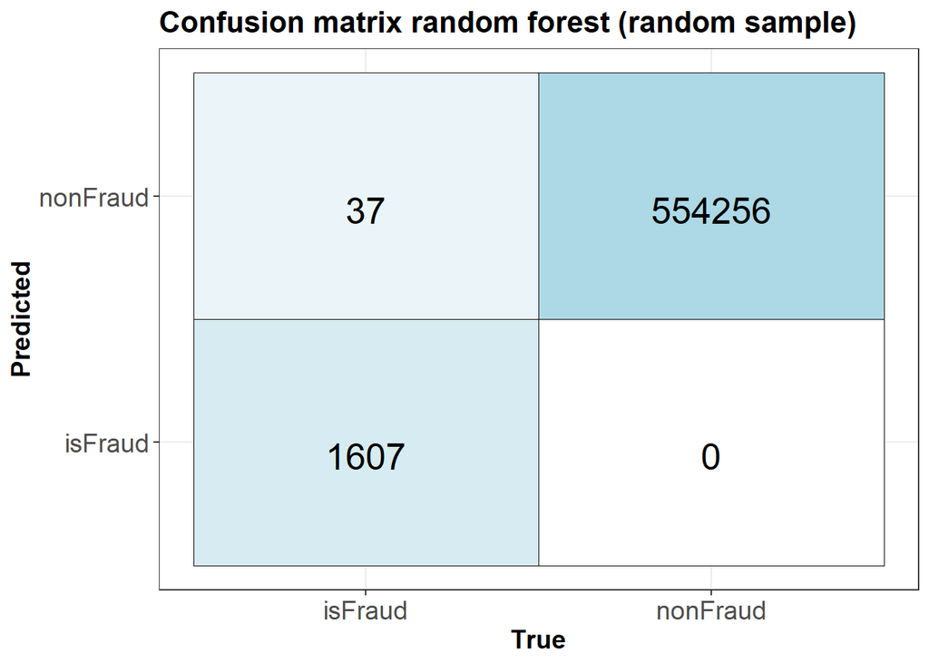

```r
Predicted <- factor(c("nonFraud", "isFraud", "isFraud", "nonFraud")) # set the possible outcomes for the predictions
True <- factor(c("nonFraud", "nonFraud", "isFraud", "isFraud")) # set the possible outcomes for the true values
ValuesRandom <- c(554256, 0, 1607, 37) # set the number of values accordingly
ValuesBalanced <- c(554119, 136, 1638, 6) # set the number of values accordingly
FillRandom <- c(2,0,1,0.5) # create a vector for later colorization for the "random" tree
FillBalanced <- c(2,0.5,1,0) # create a vector for later colorization for the "balanced" tree
dataRandom <- data.frame(True, Predicted, ValuesRandom) # combine the created vectors for the "random" tree
dataBalanced <- data.frame(True, Predicted, ValuesBalanced) # combine the created vectors for the "balanced" tree

# Confusion matrix for the random forest generated from the random sample
ggplot(data = dataRandom, mapping = aes(x = True, y = Predicted)) + # create a new ggplot with the variables created above
  geom_tile(aes(fill = FillRandom), colour = "black") + # create a geom:tile element with the fill values from above
  geom_text(aes(label = sprintf("%1.0f", ValuesRandom)), vjust = 1, size = 7) + # define the shape of the values in the plot
  scale_fill_gradient(low = "white", high = "lightblue") + # apply the above prepared filling
  theme_bw() + # set the bw theme
  theme(legend.position = "none", # no legend
        axis.text = element_text(size = 14), # define the font size of the axis texts
        axis.title = element_text(size = 14, face = "bold"), # define the font size of the axis title
        plot.title = element_text(size = 16, face = "bold")) + # define the font size of the plot title
  labs(title = "Confusion matrix random forest (random sample)") # set the plot title
```

[figure not shown]

```r
# Confusion matrix for the balanced forest generated from the random sample
ggplot(data = dataBalanced, mapping = aes(x = True, y = Predicted)) + # create a new ggplot with the variables created above
  geom_tile(aes(fill = FillBalanced), colour = "black") + # create a geom:tile element with the fill values from above
  geom_text(aes(label = sprintf("%1.0f", ValuesBalanced)), vjust = 1, size = 7) + # define the shape of the values in the plot
  scale_fill_gradient(low = "white", high = "lightblue") + # apply the above prepared filling
  theme_bw() + # set the bw theme
  theme(legend.position = "none", # no legend
        axis.text = element_text(size = 14), # define the font size of the axis texts
        axis.title = element_text(size = 14, face = "bold"), # define the font size of the axis title
        plot.title = element_text(size = 16, face = "bold")) + # define the font size of the plot title
  labs(title = "Confusion matrix random forest (balanced sample)") # set the plot title
```

In the following, the barplot for the variable importance for both models will be plotted.

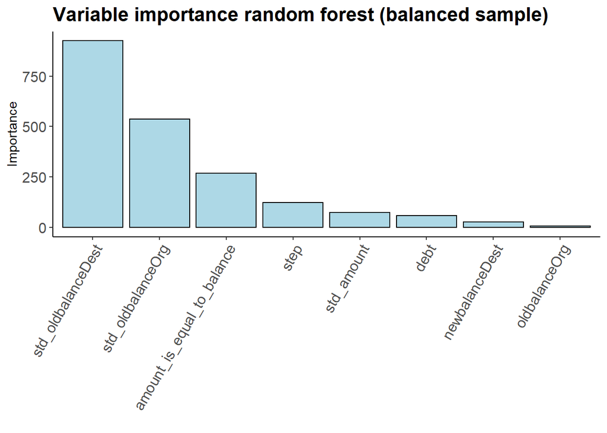

```r
importanceBalanced <- varImp(BalancedForest) # get the variable importance of the balanced forest
importanceBalanced$features <- row.names(importance) # get the rownames

importanceRandom <- varImp(randForest) # get the variable importance of the random forest
importanceRandom$features <- row.names(importance) # get the rownames

ggplot(importanceBalanced) + # create a new ggplot with importance as data
  geom_bar(stat = "identity", aes(x = reorder(features, -Overall), y = Overall), fill = "lightblue", color = "black") + # put features on the x-axis and importance on the y-axis
  theme(axis.text.x = element_text(angle = 60, vjust = 1, hjust = 1), # flip the x-axis labels
        panel.background = element_rect(fill = "white"),
        axis.line=element_line(color="black"),
        axis.text = element_text(size = 12),
        plot.title = element_text(size = 16, face = "bold")) + # flip x-axis labels
  labs(title = "Variable importance random forest (balanced sample)", # set white background
       x = "", # set empty x-axis title
       y = "Importance") # set the title
```

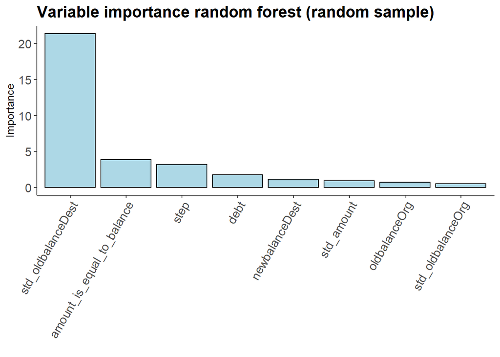

```r
ggplot(importanceRandom) + # create a new ggplot with importance as data
  geom_bar(stat = "identity", aes(x = reorder(features, -Overall), y = Overall), fill = "lightblue", color = "black") + # put features on the x-axis and importance on the y-axis
  theme(axis.text.x = element_text(angle = 60, vjust = 1, hjust = 1), # flip the x-axis labels
        panel.background = element_rect(fill = "white"),
        axis.line = element_line(color="black"),
        axis.text = element_text(size = 12),
        plot.title = element_text(size = 16, face = "bold")) + # flip x-axis labels
  labs(title = "Variable importance random forest (random sample)", # set white background
       x = "", # set empty x-axis title
       y = "Importance") # set the title
```

## Neural Network

### Finding the optimal combination of layers and nodes

In this first step, the optimal combination of layers and nodes shall be found, therefore different combinations of nodes and layers of up to 9 layers, containing 9 nodes will be evaluated for the both of the “small” training sets to later on apply a network with these characteristics to the “real” training set. This avoids arbitrarily choosing a combination.

```r
la <- 81 # set the length to 81 (initially 100, but due to computational time, only 81 what allows all combination with 9 nodes and 9 hidden layers)

# create a data table to store the performance values (sensitivity, specificity, accuracy) for the single combinations of nodes and layers
performance <- data.table("Layers" = numeric(la),
                          "Nodes" = numeric(la),
                          "SensitivityBalanced" = numeric(la),
                          "SensitivityRandom" = numeric(la),
                          "SpecificityBalanced" = numeric(la),
                          "SpecificityRandom" = numeric(la),
                          "AccuracyBalanced" = numeric(la),
                          "AccuracyRandom" = numeric(la))

results <- data.table("PredictionBalanced" = as.factor(0), "PredictionRandom" = as.factor(0), "True" = validation[,9]) # create a table for the predictions and real outcomes of the test set

# compile functions to save computational time
newNeuralNetwork <- cmpfun(neuralnet) # compile the function "neuralnet"
comp <- cmpfun(neuralnet::compute) # compile the function compute from neuralnet

# The 2 loops go though all combinations of layers and nodes, calculate the respective neural network and evaluate its performance with the test set

for (j in 1:9){ # go through all layers
  for (i in 1:9){ # go through all nodes
    performance[(j-1)*9+i,1] = j # assign the number of layers
    performance[(j-1)*9+i,2] = i # assign the number of nodes
    print(paste("i:", i))
    print(paste("j:", j))
    if (j == 1){
      # calculate the neural networks for the current combination of nodes per layer i and 1 hidden layer for both "small" training samples
      set.seed(1)
      currentBalanced <- newNeuralNetwork(isFraud ~ ., data = trainSmall, hidden = i, linear.output = FALSE)
      currentRandom <- newNeuralNetwork(isFraud ~ ., data = trainSmall, hidden = i, linear.output = FALSE)
    }
    if (j == 2){
      # calculate the neural networks for the current combination of nodes per layer i and 2 hidden layers for both "small" training samples
      set.seed(1)
      currentBalanced <- newNeuralNetwork(isFraud ~ ., data = trainSmall, hidden = c(i,i), linear.output = FALSE)
      currentRandom <- newNeuralNetwork(isFraud ~ ., data = trainSmall, hidden = c(i,i), linear.output = FALSE)
    }
    if(j == 3){
      # calculate the neural networks for the current combination of nodes per layer i and 3 hidden layers for both "small" training samples
      set.seed(1)
      currentBalanced <- newNeuralNetwork(isFraud ~ ., data = trainSmall, hidden = c(i,i,i), linear.output = FALSE)
      currentRandom <- newNeuralNetwork(isFraud ~ ., data = trainSmall, hidden = c(i,i,i), linear.output = FALSE)
    }
    if(j == 4){
      # calculate the neural networks for the current combination of nodes per layer i and 4 hidden layers for both "small" training samples
      set.seed(1)
      currentBalanced <- newNeuralNetwork(isFraud ~ ., data = trainSmall, hidden = c(i,i,i,i), linear.output = FALSE)
      currentRandom <- newNeuralNetwork(isFraud ~ ., data = trainSmall, hidden = c(i,i,i,i), linear.output = FALSE)
    }
    if(j == 5){
      # calculate the neural networks for the current combination of nodes per layer i and 5 hidden layers for both "small" training samples
      set.seed(1)
      currentBalanced <- newNeuralNetwork(isFraud ~ ., data = trainSmall, hidden = c(i,i,i,i,i), linear.output = FALSE)
      currentRandom <- newNeuralNetwork(isFraud ~ ., data = trainSmall, hidden = c(i,i,i,i,i), linear.output = FALSE)
    }
    if(j == 6){
      set.seed(1)
      currentBalanced <- newNeuralNetwork(isFraud ~ ., data = trainSmall, hidden = c(i,i,i,i,i,i), linear.output = FALSE) # calculate the neural network for the current combination of nodes per layer and 6 hidden layers
      currentRandom <- newNeuralNetwork(isFraud ~ ., data = trainSmall, hidden = c(i,i,i,i,i,i), linear.output = FALSE)
    }
    if(j == 7){
      # calculate the neural networks for the current combination of nodes per layer i and 7 hidden layers for both "small" training samples
      set.seed(1)
      currentBalanced <- newNeuralNetwork(isFraud ~ ., data = trainSmall, hidden = c(i,i,i,i,i,i,i), linear.output = FALSE) # calculate the neural network for the current combination of nodes per layer and 7 hidden layers
      currentRandom <- newNeuralNetwork(isFraud ~ ., data = trainSmall, hidden = c(i,i,i,i,i,i,i), linear.output = FALSE)
    }
    if(j == 8){
      # calculate the neural networks for the current combination of nodes per layer i and 8 hidden layers for both "small" training samples
      set.seed(1)
      currentBalanced <- newNeuralNetwork(isFraud ~ ., data = trainSmall, hidden = c(i,i,i,i,i,i,i,i), linear.output = FALSE)
      currentRandom <- newNeuralNetwork(isFraud ~ ., data = trainSmall, hidden = c(i,i,i,i,i,i,i,i), linear.output = FALSE)
    }
    if(j == 9){
      # calculate the neural networks for the current combination of nodes per layer i and 9 hidden layers for both "small" training samples
      set.seed(1)
      currentBalanced <- newNeuralNetwork(isFraud ~ ., data = trainSmall, hidden = c(i,i,i,i,i,i,i,i,i), linear.output = FALSE)
      currentRandom <- newNeuralNetwork(isFraud ~ ., data = trainSmall, hidden = c(i,i,i,i,i,i,i,i,i), linear.output = FALSE)
    }
    print("-")
    results$PredictionBalanced <- as.factor(round(comp(currentBalanced, validation)$net.result[,2])) # predictions for the validation set
    results$PredictionRandom <- as.factor(round(comp(currentRandom, validation)$net.result[,2])) # predictions for the validation set

    performance[(j-1)*9+i,3] <- sensitivity(results$PredictionBalanced, results$True.isFraud) # calculate sensitivity
    performance[(j-1)*9+i,4] <- sensitivity(results$PredictionRandom, results$True.isFraud) # calculate sensitivity
    performance[(j-1)*9+i,5] <- specificity(results$PredictionBalanced, results$True.isFraud) # calculate specificity
    performance[(j-1)*9+i,6] <- specificity(results$PredictionRandom, results$True.isFraud) # calculate specificity
    performance[(j-1)*9+i,7] <- confusionMatrix(results$PredictionBalanced, results$True.isFraud, positive = "1")$overall[1] # get the overall accuracy for the balanced training sample
    performance[(j-1)*9+i,8] <- confusionMatrix(results$PredictionRandom, results$True.isFraud, positive = "1")$overall[1] # get the overall accuracy for the random training sample
  }
}
```

```
## [1] "i: 1"
## [1] "j: 1"
## [1] "-"
## [1] "i: 2"
## [1] "j: 1"
## [1] "-"
## [1] "i: 3"
## [1] "j: 1"
## [1] "-"
## [1] "i: 4"
## [1] "j: 1"
## [1] "-"
## [1] "i: 5"
## [1] "j: 1"
## [1] "-"
```

[output cut: 228 more lines]

In the following, the performances will be evaluated. The performance table will be ordered by SensitivityBalanced.

```r
performance <- na.omit(performance) # leave out NAs that might have appeared, using try
performance <- performance[order(-SensitivityBalanced),] # reorder it by SensitivityTest
kable(head(performance, 10)) # show the first rows of the performance table
```

| Layers | Nodes | SensitivityBalanced | SensitivityRandom | SpecificityBalanced | SpecificityRandom | AccuracyBalanced | AccuracyRandom |
| --- | --- | --- | --- | --- | --- | --- | --- |
| 8 | 8 | 0.9999952 | 0.9997596 | 0.9968279 | 0.9968279 | 0.9999855 | 0.9997507 |
| 9 | 8 | 0.9999952 | 0.9984358 | 0.9968279 | 0.9968279 | 0.9999855 | 0.9984309 |
| 9 | 7 | 0.9999928 | 0.9998237 | 0.9968279 | 0.9968279 | 0.9999831 | 0.9998146 |
| 7 | 8 | 0.9999855 | 0.9999456 | 0.9968279 | 0.9968279 | 0.9999759 | 0.9999362 |
| 8 | 9 | 0.9999855 | 0.9999928 | 0.9968279 | 0.9968279 | 0.9999759 | 0.9999831 |
| 1 | 4 | 0.9999843 | 0.9999710 | 0.9968279 | 0.9968279 | 0.9999747 | 0.9999615 |
| 5 | 7 | 0.9999843 | 0.9998647 | 0.9968279 | 0.9968279 | 0.9999747 | 0.9998555 |
| 1 | 7 | 0.9999771 | 0.9980928 | 0.9968279 | 0.9972244 | 0.9999675 | 0.9980901 |
| 3 | 6 | 0.9999771 | 0.9994178 | 0.9968279 | 0.9972244 | 0.9999675 | 0.9994111 |
| 4 | 6 | 0.9999758 | 0.9998188 | 0.9968279 | 0.9968279 | 0.9999663 | 0.9998097 |

The best trade-off between complexity and performance seems to be the the network with 1 hidden layer with 4 nodes. This one will be used in the following to be computed with the whole training set and then evaluated with the validation set.

```r
current <- newNeuralNetwork(isFraud ~ ., data = train, hidden = 4, linear.output = FALSE) # calculate the neural network with 1 hidden layer with 4 nodes, that has previously been evaluated as the "best"

performanceNet <- data.table("Prediction" = as.factor(round(comp(current, test)$net.result[,2])), "True" = test[,9]) # create a data table to store the predictions and the true values

confusionMatrix(performanceNet$Prediction, performanceNet$True.isFraud, positive = "1") # create the confusion matrix
```

```
## Confusion Matrix and Statistics
##
##           Reference
## Prediction      0      1
##          0 554256      7
##          1      0   1637
##
##                Accuracy : 1
##                  95% CI : (1, 1)
##     No Information Rate : 0.997
##     P-Value [Acc > NIR] : < 0.0000000000000002
##
##                   Kappa : 0.9979
##
##  Mcnemar's Test P-Value : 0.02334
##
##             Sensitivity : 0.995742
##             Specificity : 1.000000
##          Pos Pred Value : 1.000000
##          Neg Pred Value : 0.999987
##              Prevalence : 0.002957
##          Detection Rate : 0.002945
##    Detection Prevalence : 0.002945
##       Balanced Accuracy : 0.997871
##
##        'Positive' Class : 1
##
```

### Presenting the results

2 confusion matrices will be produced.

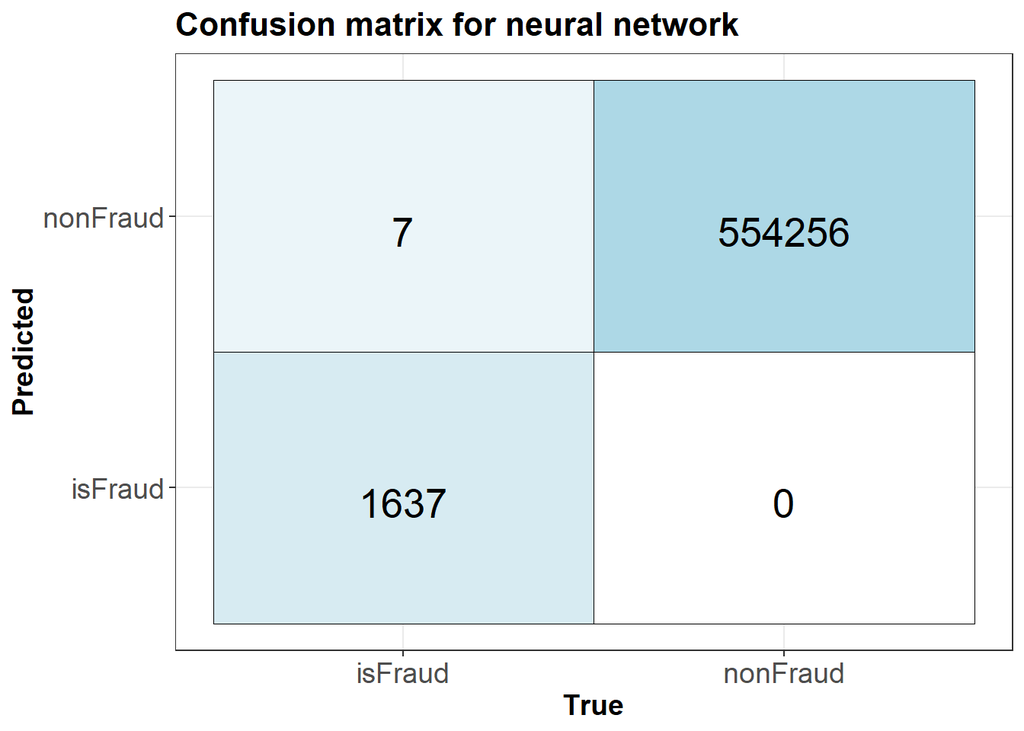

```r
Predicted <- factor(c("nonFraud", "isFraud", "isFraud", "nonFraud")) # set the possible outcomes for the predictions
True <- factor(c("nonFraud", "nonFraud", "isFraud", "isFraud")) # set the possible outcomes for the true values
Values      <- c(554256, 0, 1637, 7) # set the number of values accordingly
Fill <- c(2,0,1,0.5) # create a vector for later colorization
data <- data.frame(True, Predicted, Values) # combine the created vectors

ggplot(data =  data, mapping = aes(x = True, y = Predicted)) + # create a new ggplot with the variables created above
  geom_tile(aes(fill = Fill), colour = "black") + # create a geom:tile element with the fill values from above
  geom_text(aes(label = sprintf("%1.0f", Values)), vjust = 1, size = 7) + # define the shape of the values in the plot
  scale_fill_gradient(low = "white", high = "lightblue") + # apply the above prepared filling
  theme_bw() + # set the bw theme
  theme(legend.position = "none", # no legend
        axis.text = element_text(size = 14), # define the font size of the axis texts
        axis.title = element_text(size = 14, face = "bold"), # define the font size of the axis title
        plot.title = element_text(size = 16, face = "bold")) + # define the font size of the plot title
  labs(title = "Confusion matrix for neural network") # set the plot title
```

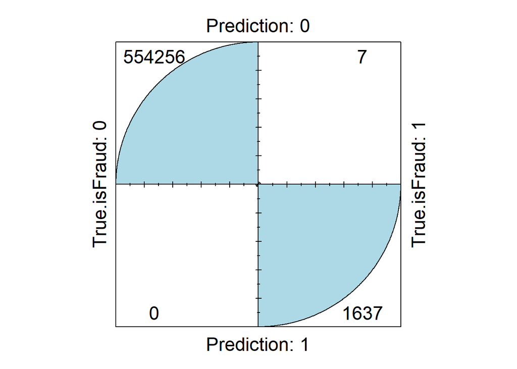

```r
fourfoldplot(table(performanceNet), color = c("red", "lightblue")) # create a second confusion matrix as comparison
```

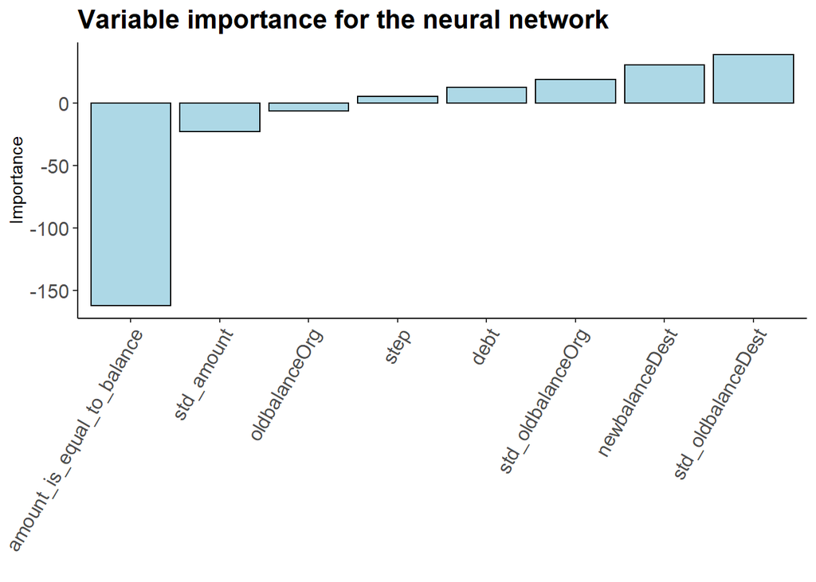

```r
# presenting the variable importances
importance <- olden(current, bar_plot=FALSE) # getting variable importances
importance$features <- row.names(importance) # getting rownames as an extra column

ggplot(importance) + # create a new ggplot with importance as data
  geom_bar(stat = "identity", aes(x = reorder(features, importance), y = importance), fill = "lightblue", color = "black") + # put features on the x-axis and importance on the y-axis
  theme(axis.text.x = element_text(angle = 60, vjust = 1, hjust = 1), # flip the x-axis labels
        panel.background = element_rect(fill = "white"),
        axis.line=element_line(color="black"),
        axis.text = element_text(size = 12),
        plot.title = element_text(size = 16, face = "bold")) + # flip x-axis labels
  labs(title = "Variable importance for the neural network", # set white background
       x = "", # set empty x-axis title
       y = "Importance") # set the title
```

```r
plot(current, # the data shall be the previously calculated network
     show.weights = FALSE, # do not show weights because it would be to full
     information = FALSE, # do not give any additional information
     fill = 'lightblue') # fill the nodes with lightblue
```

[output not shown]

## Graphs from Python

In this abstract, the graphs for the methods that were implemented in Python will be produced. For this, the data from Python will be copied.

### Graphs for knn

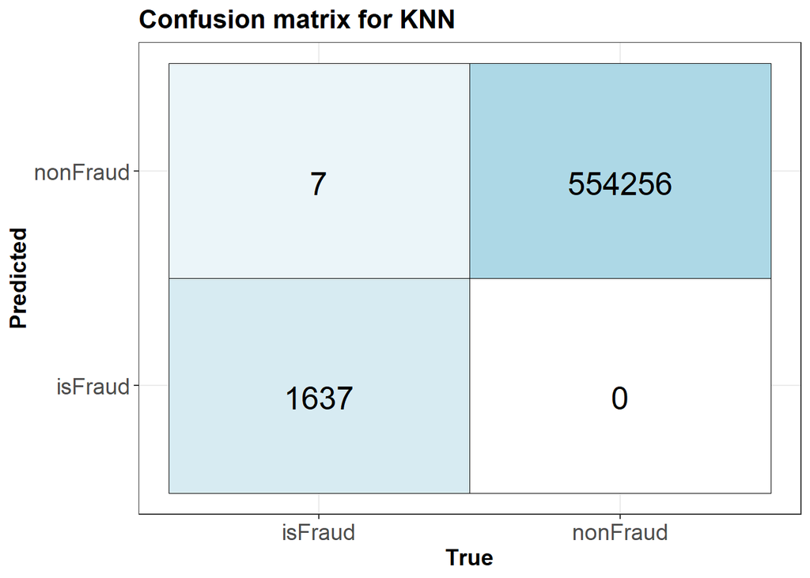

```r
Predicted <- factor(c("nonFraud", "isFraud", "isFraud", "nonFraud")) # set the possible outcomes for the predictions
True <- factor(c("nonFraud", "nonFraud", "isFraud", "isFraud")) # set the possible outcomes for the true values
Values      <- c(554256, 0, 1637, 7) # set the number of values accordingly
Fill <- c(2,0,1,0.5) # create a vector for later colorization
data <- data.frame(True, Predicted, Values) # combine the created vectors

ggplot(data =  data, mapping = aes(x = True, y = Predicted)) + # create a new ggplot with the variables created above
  geom_tile(aes(fill = Fill), colour = "black") + # create a geom:tile element with the fill values from above
  geom_text(aes(label = sprintf("%1.0f", Values)), vjust = 1, size = 7) + # define the shape of the values in the plot
  scale_fill_gradient(low = "white", high = "lightblue") + # apply the above prepared filling
  theme_bw() + # set the bw theme
  theme(legend.position = "none", # no legend
        axis.text = element_text(size = 14), # define the font size of the axis texts
        axis.title = element_text(size = 14, face = "bold"), # define the font size of the axis title
        plot.title = element_text(size = 16, face = "bold")) + # define the font size of the plot title
  labs(title = "Confusion matrix for KNN") # set the plot title
```

[figure not shown]

```r
importance <- olden(current, bar_plot=FALSE) # getting variable importances
importance$features <- row.names(importance) # getting rownames as an extra column

ggplot(importance) + # create a new ggplot with importance as data
  geom_bar(stat = "identity", aes(x = reorder(features, importance), y = importance), fill = "lightblue", color = "black") + # put features on the x-axis and importance on the y-axis
  theme(axis.text.x = element_text(angle = 60, vjust = 1, hjust = 1), # flip the x-axis labels
        panel.background = element_rect(fill = "white"), # set the background to white
        axis.line = element_line(color = "black"), # set the axis color to black
        axis.text = element_text(size = 12), # set the axis labels size
        plot.title = element_text(size = 16, face = "bold")) + # flip x-axis labels
  labs(title = "Variable importance for KNN", # set the title
       x = "", # set empty x-axis title
       y = "Importance") # set the title
```

### Graphs for Naive Bayes

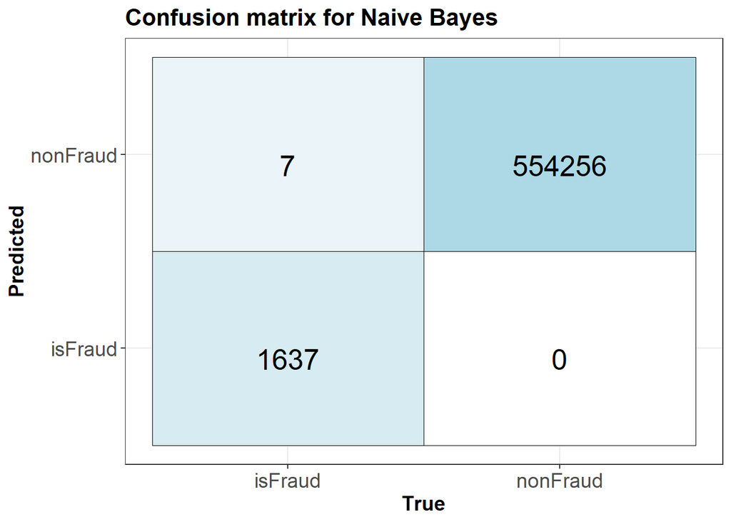

```r
Predicted <- factor(c("nonFraud", "isFraud", "isFraud", "nonFraud")) # set the possible outcomes for the predictions
True <- factor(c("nonFraud", "nonFraud", "isFraud", "isFraud")) # set the possible outcomes for the true values
Values      <- c(554256, 0, 1637, 7) # set the number of values accordingly
Fill <- c(2,0,1,0.5) # create a vector for later colorization
data <- data.frame(True, Predicted, Values) # combine the created vectors

ggplot(data =  data, mapping = aes(x = True, y = Predicted)) + # create a new ggplot with the variables created above
  geom_tile(aes(fill = Fill), colour = "black") + # create a geom:tile element with the fill values from above
  geom_text(aes(label = sprintf("%1.0f", Values)), vjust = 1, size = 7) + # define the shape of the values in the plot
  scale_fill_gradient(low = "white", high = "lightblue") + # apply the above prepared filling
  theme_bw() + # set the bw theme
  theme(legend.position = "none", # no legend
        axis.text = element_text(size = 14), # define the font size of the axis texts
        axis.title = element_text(size = 14, face = "bold"), # define the font size of the axis title
        plot.title = element_text(size = 16, face = "bold")) + # define the font size of the plot title
  labs(title = "Confusion matrix for Naive Bayes") # set the plot title
```

[figure not shown]

```r
importance <- olden(current, bar_plot=FALSE) # getting variable importances
importance$features <- row.names(importance) # getting rownames as an extra column

ggplot(importance) + # create a new ggplot with importance as data
  geom_bar(stat = "identity", aes(x = reorder(features, importance), y = importance), fill = "lightblue", color = "black") + # put features on the x-axis and importance on the y-axis
  theme(axis.text.x = element_text(angle = 60, vjust = 1, hjust = 1), # flip the x-axis labels
        panel.background = element_rect(fill = "white"), # set the background to white
        axis.line = element_line(color = "black"), # set the axis color to black
        axis.text = element_text(size = 12), # set the axis labels size
        plot.title = element_text(size = 16, face = "bold")) + # flip x-axis labels
  labs(title = "Variable importance for Naive Bayes", # set the title
       x = "", # set empty x-axis title
       y = "Importance") # set the title
```

### Graphs for Ensembles

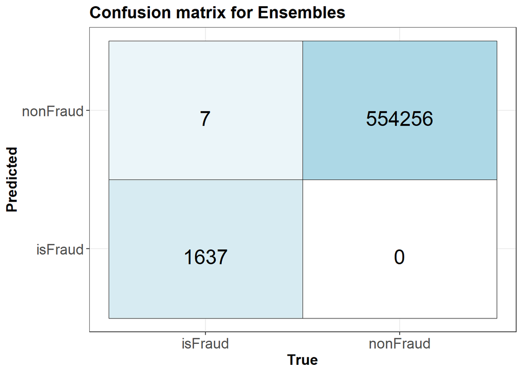

```r
Predicted <- factor(c("nonFraud", "isFraud", "isFraud", "nonFraud")) # set the possible outcomes for the predictions
True <- factor(c("nonFraud", "nonFraud", "isFraud", "isFraud")) # set the possible outcomes for the true values
Values      <- c(554256, 0, 1637, 7) # set the number of values accordingly
Fill <- c(2,0,1,0.5) # create a vector for later colorization
data <- data.frame(True, Predicted, Values) # combine the created vectors

ggplot(data =  data, mapping = aes(x = True, y = Predicted)) + # create a new ggplot with the variables created above
  geom_tile(aes(fill = Fill), colour = "black") + # create a geom:tile element with the fill values from above
  geom_text(aes(label = sprintf("%1.0f", Values)), vjust = 1, size = 7) + # define the shape of the values in the plot
  scale_fill_gradient(low = "white", high = "lightblue") + # apply the above prepared filling
  theme_bw() + # set the bw theme
  theme(legend.position = "none", # no legend
        axis.text = element_text(size = 14), # define the font size of the axis texts
        axis.title = element_text(size = 14, face = "bold"), # define the font size of the axis title
        plot.title = element_text(size = 16, face = "bold")) + # define the font size of the plot title
  labs(title = "Confusion matrix for Ensembles") # set the plot title
```

[figure not shown]

```r
importance <- olden(current, bar_plot = FALSE) # getting variable importances
importance$features <- row.names(importance) # getting rownames as an extra column

ggplot(importance) + # create a new ggplot with importance as data
  geom_bar(stat = "identity", aes(x = reorder(features, importance), y = importance), fill = "lightblue", color = "black") + # put features on the x-axis and importance on the y-axis
  theme(axis.text.x = element_text(angle = 60, vjust = 1, hjust = 1), # flip the x-axis labels
        panel.background = element_rect(fill = "white"), # set the background to white
        axis.line = element_line(color = "black"), # set the axis color to black
        axis.text = element_text(size = 12), # set the axis labels size
        plot.title = element_text(size = 16, face = "bold")) + # flip x-axis labels
  labs(title = "Variable importance for Ensembles", # set the title
       x = "", # set empty x-axis title
       y = "Importance") # set the title
```